# Group K Final Project

Author

Jack Vogel, Troy Volpentest, Diego Nieves, Jeffrey Cheung

## Section 1: Project Proposal + Data

Download PlaneCrashAffected_AnnualNumber.csv data

Download freedix_fh.csv data

```r
library(tidyverse)
library(gganimate)
library(knitr)
library(kableExtra)
library(broom)
planeCrashAffected <- read.csv("PlaneCrashAffected_AnnualNumber.csv")
FH <- read.csv("freedix_fh.csv")
```

### 1.1 Data Cleaning

```r
colnames(planeCrashAffected) <- str_remove(colnames(planeCrashAffected), "^X")
colnames(FH) <- str_remove(colnames(FH), "^X")
```

### 1.2 Pivoting Longer

```r
PCAffectedLong <- planeCrashAffected |>
  pivot_longer(cols = -country,
               names_to = "year",
               values_to = "num_people_affected")

FHLong <- FH |>
  pivot_longer(cols = -country,
               names_to = "year",
               values_to = "FH")
```

### 1.3 Joining Datasets

```r
JoinedData <- PCAffectedLong |>
  inner_join(FHLong, by = c("country", "year"))
```

In this analysis, we use data from the Freedom House Organization’s Freedom Index which is an aggregate score representing a country’s political and civil freedoms in a given year. A country’s freedom score is based on a scale from 1(most free) to 7(least free). The political rights section of a country’s Freedom Index score is based on their electoral process, political pluralism and participation. The civil liberties category is based on the people’s Freedom of Expression and Belief, Associational and Organizational Rights, Rule of Law and Personal Autonomy and Individual Rights. We also use data from the Plane Crash Affected Annual Number dataset from gapminder. This dataset includes information on the total number of people affected, injured or killed in air accidents during the given year.

For our data cleaning, each year column began with “^X” (eg. “^X1993”), which we removed. FH goes from 1972 to 2020, while plane crash data goes from 1970 to 2008, so our final dataset uses years from 1972 to 2008.

## Section 2: Linear Regression

### 2.1 Data Visualization

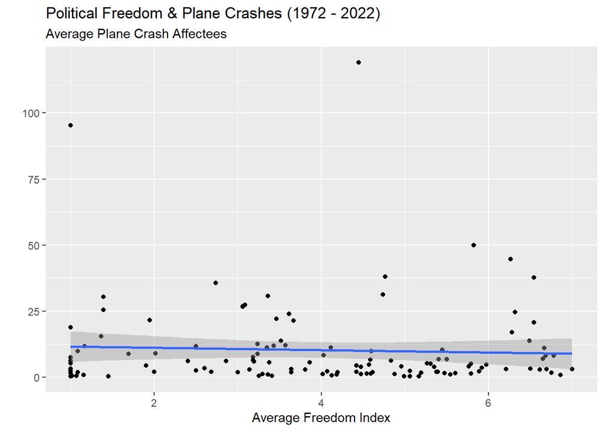

```r
JoinedData <- JoinedData |>
  drop_na(FH, num_people_affected)

countryAverages <- JoinedData |>
  group_by(country) |>
  summarize(avg_FH = mean(FH, na.rm = TRUE),
            avg_people_affected = mean(num_people_affected, na.rm = TRUE))



ggplot(countryAverages,
       aes(x = avg_FH, y = avg_people_affected))+
  geom_point() +
  geom_smooth(method = "lm") +
  labs(title = "Political Freedom & Plane Crashes (1972 - 2022)",
       subtitle = "Average Plane Crash Affectees",
       x = "Average Freedom Index", y = "")
```

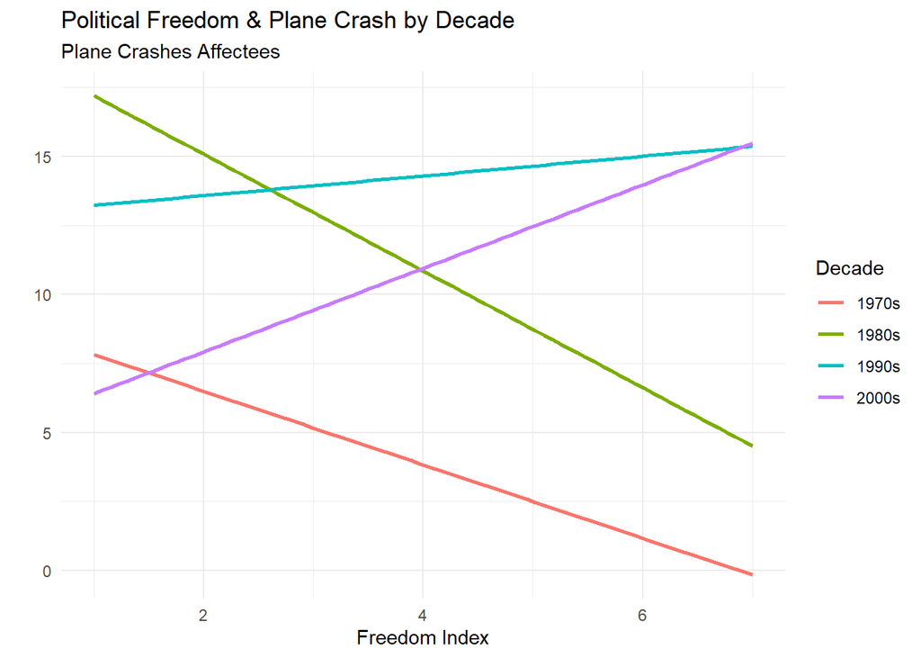

```r
JoinedData |>
  mutate(decade = paste0(floor(as.numeric(year) / 10) * 10, "s")) |>

  ggplot(aes(x = FH, y = num_people_affected, color = as.factor(decade))) +
  geom_smooth(method = "lm", se = FALSE) +
  labs(title = "Political Freedom & Plane Crash by Decade",
       subtitle = "Plane Crashes Affectees",
       x = "Freedom Index",
       y = "",
       color = "Decade") +
  theme_minimal()
```

Now this graph illustrates the same relationship except it demonstrates throughout decades. (1970s–2000s). The trends vary significantly, as the 1970s and 1980s show a ‘negative’ correlation, more freedom associated with more crash victims, while the 1990s and 2000s exhibit a ‘positive’ correlation less freedom associated with more crash victims. The opposing trends do suggest a correlation that the relationship has changed over time, but with the lines varying greatly, it could just be a coincidence.